The following examples illustrates the computation of a relative terrain elevation matrix based on micro relief measurements along slope parallel and perpendicular lines.

### Workflow

The workflow is straight forward (althouhg maybe a little hard to understand): 1. Compute the relative height changes in slope parallel direction relative to the left-most values of each line. 2. Compute the relative height changes in slope downard direction relative to the upper-most values of each line. 3. Correct the left-most values of the parallel lines by the left-most downward-slope height levels.

### Reading the data

We use the data from [Reading micro-topography sheets](http://moc.environmentalinformatics-marburg.de/doku.php?id=courses:bsc:project-thesis-geoei:lecture-notes:bdh:pt-ge-ln-bdh-01-2080_topography) and start directly with the two final data blocks that contain the slope parallel and slope downward measurement values.

[output not shown]

```r
head(fdb)
```

```
##    Hangparallel D0-1m D1-2m D2-3m D3-4m D4-5m PlotID
## 9      0m Linie   6.0   9.0  -1.5  -3.0   1.0    050
## 10     1m Linie  -1.0   8.0   3.5   8.0  -6.5    050
## 11     2m Linie   7.0   0.0  15.0 -10.0  -8.5    050
## 12     3m Linie  -9.5  -1.5   0.0  -2.0  -7.0    050
## 13     4m Linie   4.5  -5.0   0.5  -6.0  -7.5    050
## 14     5m Linie -17.5  -6.5  -1.5  -0.5 -11.5    050
```

```r
head(sdb)
```

```
##    Hangabwaerts D0m Linie D1m Linie D2m Linie D3m Linie D4m Linie    NA
## 20         0-1m     -31.0     -37.0     -35.5     -32.5     -22.5 -30.5
## 21         1-2m     -31.0     -28.0     -35.0     -20.0     -37.5 -25.0
## 22         2-3m     -24.5     -33.5     -31.0     -44.0     -41.0 -39.0
## 23         3-4m     -36.5     -38.0     -40.0     -39.0     -43.5 -35.5
## 24         4-5m     -27.0     -41.0     -39.0     -33.5     -34.0 -33.0
##    PlotID
## 20    050
## 21    050
## 22    050
## 23    050
## 24    050
```

Before we start computing the actual relative terrain model, we homogenize the datasets and produce to long-format data frames, one for the slope parallel (sp) and one for the slope downward (sd) measurements.

These values have been meassured along the lines of a rectangular grid of 5 by 5 meter with 1 m space between two adjacent slope parallel/downward lines. It looks something like that: SD… 0 1 2 3 4 5 SP0 |-|-|-|-|-| SP1 |-|-|-|-|-| SP2 |-|-|-|-|-| SP3 |-|-|-|-|-| SP4 |-|-|-|-|-| SP5 |-|-|-|-|-|

```r
library(reshape2)

sp <- melt(fdb[1:6,], c("Hangparallel", "PlotID"))
sp$Direction <- "SP"
sp$Hangparallel <- paste0("SP", substr(sp$Hangparallel, 1, 1))
sp$variable <- paste0("SD", substr(sp$variable, 4,4))
colnames(sp) <- c("SPLoc", "PlotID", "SDLoc", "dH", "Direction")
sp <- sp[,c("PlotID", "Direction", "SPLoc", "SDLoc", "dH")]
head(sp)
```

```
##   PlotID Direction SPLoc SDLoc    dH
## 1    050        SP   SP0   SD1   6.0
## 2    050        SP   SP1   SD1  -1.0
## 3    050        SP   SP2   SD1   7.0
## 4    050        SP   SP3   SD1  -9.5
## 5    050        SP   SP4   SD1   4.5
## 6    050        SP   SP5   SD1 -17.5
```

```r
sd <- melt(sdb[,-7], c("Hangabwaerts", "PlotID"))
sd$Direction <- "SD"
sd$Hangabwaerts <- paste0("SP", substr(sd$Hangabwaerts, 3, 3))
sd$variable <- paste0("SD", substr(sd$variable, 2,2))
colnames(sd) <- c("SPLoc", "PlotID", "SDLoc", "dH", "Direction")
sd <- sd[,c("PlotID", "Direction", "SPLoc", "SDLoc", "dH")]
head(sd)
```

```
##   PlotID Direction SPLoc SDLoc    dH
## 1    050        SD   SP1   SD0 -31.0
## 2    050        SD   SP2   SD0 -31.0
## 3    050        SD   SP3   SD0 -24.5
## 4    050        SD   SP4   SD0 -36.5
## 5    050        SD   SP5   SD0 -27.0
## 6    050        SD   SP1   SD1 -37.0
```

Once we have these long-data frames, we can start with the computation.

First, we compute the vertical differences along each slope parallel. Afterwards we do the same for each slope downward line. The latter would be enough to do it only for the first one since we need only the leftmost downslope line to adjust the terrain values along the slope parallels relative to the upper left corner.

```r
# Loop over all slope parallels
slope_parallels <- lapply(unique(sp$SPLoc), function(act_parallel){
  # Loop over all vertical lines along a specific slope parallel
  act_line <- lapply(seq(length(unique(sp$SDLoc))), function(x){
    sum(sp$dH[sp$SPLoc == act_parallel][seq(x)])
  })
  return(c(0, unlist(act_line)))
})
slope_parallels <- do.call("rbind", slope_parallels)



# Loop over all slope verticals
slope_verticals <- lapply(unique(sd$SDLoc), function(act_vertical){
  # Loop over all parallels  along a specific slope vertical
  act_line <- lapply(seq(length(unique(sd$SPLoc))), function(x){
    sum(sd$dH[sd$SDLoc == act_vertical][seq(x)])
  })
  return(c(0, unlist(act_line)))
})
slope_verticals <- t(do.call("rbind", slope_verticals))

grid <- slope_parallels + slope_verticals[,1]
grid
```

```
##        [,1]   [,2]   [,3]   [,4]   [,5]   [,6]
## [1,]    0.0    6.0   15.0   13.5   10.5   11.5
## [2,]  -31.0  -32.0  -24.0  -20.5  -12.5  -19.0
## [3,]  -62.0  -55.0  -55.0  -40.0  -50.0  -58.5
## [4,]  -86.5  -96.0  -97.5  -97.5  -99.5 -106.5
## [5,] -123.0 -118.5 -123.5 -123.0 -129.0 -136.5
## [6,] -150.0 -167.5 -174.0 -175.5 -176.0 -187.5
```

This is already the final matrix. If we want to e.g. interpolate it, we can define a raster as the interpolation target, convert the just created matrix to a spatial points data frame in the same projection as the raster(which is technically necessary but this does not actually georeference the data set) and interpolate the values into the raster.

```r
library(raster)
library(gstat)

grid <- melt(as.data.frame(grid))
grid$X <- as.numeric(substr(grid$variable, 2, 2))
grid$Y <- seq(6, 1, -1)
grid$variable <- NULL
rownames(grid) <- NULL
coordinates(grid) <- ~X+Y
projection(grid) <- CRS("+proj=longlat +datum=WGS84 +ellps=WGS84 +towgs84=0,0,0")

rtm <- raster(ncols=10, nrows=10)
extent(rtm) <- extent(grid)

interpolation_model <- gstat(id = "value", formula = value~1, data = grid)
rtm_interpolated <- interpolate(rtm, interpolation_model)
```

```
## [inverse distance weighted interpolation]
```

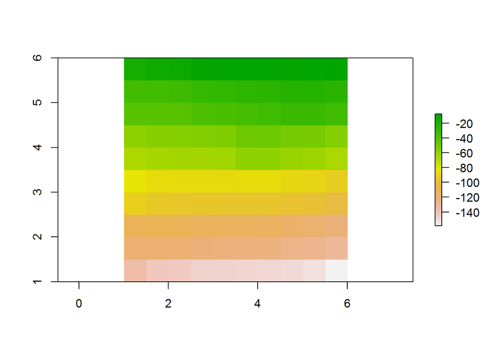

```r
plot(rtm_interpolated)
```

If we prefer 3D, we can do something like that.

```r
library(rasterVis)
```

```r
plot3D(rtm_interpolated)
```